# Assessment health insurance dataset.

## 1. Счёт данных с БД + предобработка данных.

```python
#Подключение библиотек для работы с данными.
import numpy as np
import pandas as pd
import seaborn as sns
import matplotlib.pyplot as plt
%matplotlib inline
```

#### Считаем данные из csv файла в объект Pandas, DataFrame.

```python
data = pd.read_csv('E:\ds_internship_task\ds_internship_task\insurance.csv')
#Ознакомимся с частью данных, чтобы иметь представление о БД.
data.head(10)
```

|  | age | sex | bmi | children | smoker | region | charges |
| --- | --- | --- | --- | --- | --- | --- | --- |
| 0 | 19 | female | 27.900 | 0 | yes | southwest | 16884.92400 |
| 1 | 18 | male | 33.770 | 1 | no | southeast | 1725.55230 |
| 2 | 28 | male | 33.000 | 3 | no | southeast | 4449.46200 |
| 3 | 33 | male | 22.705 | 0 | no | northwest | 21984.47061 |
| 4 | 32 | male | 28.880 | 0 | no | northwest | 3866.85520 |
| 5 | 31 | female | 25.740 | 0 | no | southeast | 3756.62160 |
| 6 | 46 | female | 33.440 | 1 | no | southeast | 8240.58960 |
| 7 | 37 | female | 27.740 | 3 | no | northwest | 7281.50560 |
| 8 | 37 | male | 29.830 | 2 | no | northeast | 6406.41070 |
| 9 | 60 | female | 25.840 | 0 | no | northwest | 28923.13692 |

#### Проверим, есть ли в нашей БД пропуски.

```python
data.isnull().sum()
```

```
age         0
sex         0
bmi         0
children    0
smoker      0
region      0
charges     0
dtype: int64
```

#### Пропусков в нашей БД нет, значит редактирование данных не требуется. Можно приступать к анализу.

## 2. Предварительное знакомство с данными из БД

#### Для более детального ознакомления с данными построим гистограммы распределения признаков. Гистограмма распределения возраста, индекса массы тела. Для ознакомления с рассматриваемыми людьми.

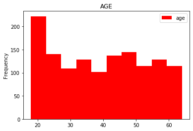

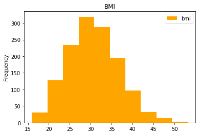

```python
data.plot(y='age', kind='hist', color='red',  title='AGE')
data.plot(y='bmi', kind='hist', color='orange',  title='BMI')
```

#### Можно сделать вывод, что в нашей БД больше всего людей в возрасте 18-22 г. Относительно усредненный показатель индекса массы тела (минимальное кол-во завышенного и заниженного показателя), что облегчает дальнейшую оценку.

#### Рассмотрим соотношение мужчин и женщин

```python
count_people = len(data.index)
count_male = (data['sex']=='male').sum()
count_female = (data['sex']=='female').sum()

print('Всего представленно {} людей, из них {} мужчин и {} женщин'.format(count_people,count_male,count_female))
```

```
Всего представленно 1338 людей, из них 676 мужчин и 662 женщин
```

#### Наблюдается примерно одинаковое количество мужчин и женщин. Так же можем оценить количетсво курящих девушек и парней.

```python
pd.options.display.float_format = '{:,.1f}'.format
data.groupby(['smoker','sex'])['sex'].count()
```

```
smoker  sex
no      female    547
        male      517
yes     female    115
        male      159
Name: sex, dtype: int64
```

#### Из полученных данных видно, что курящих 159 мужчин и 115 женщин. 0.2048 - часть курящих людей среди всех (274/1338).

#### Рассмотрим кол-во людей по регионам.

```python
data.groupby('region')['region'].count()
```

```
region
northeast    324
northwest    325
southeast    364
southwest    325
Name: region, dtype: int64
```

#### В нашей БД участвуют 4 региона: northeast, northwest, southeast, southwest.

##### Оценим рассходы людей. Посмотрим на mean,max,min значения.

```python
charge_min = round(data['charges'].min(),2)
charges_max = round(data['charges'].max(),2)
charges_mean = round(data['charges'].mean(),2)
print('Средний доход по БД на человека равен: {}. Максимальный доход: {}. Минимальный доход: {}.'.format(charges_mean,charges_max,charge_min))
```

```
Средний доход по БД на человека равен: 13270.42. Максимальный доход: 63770.43. Минимальный доход: 1121.87.
```

#### Максимальный доход намного больше среднего, это означает, что большинство людей имеет доход ближе к минимальному.

## 3. Анализ данных

#### Построим попарные зависимости признаков.

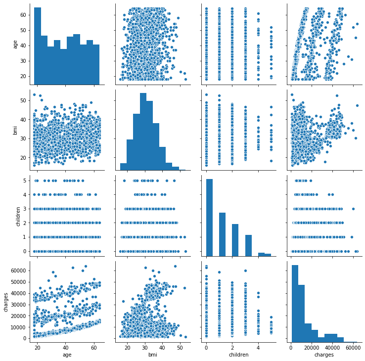

```python
sns.pairplot(data=data)
```

#### Исследуем зависимость количественного признака от катигориального. С помощью Boxplots. Так же с помощью Boxplots сможем увидеть выбросы в данных.

```
[Text(0, 0.5, 'Расход'), Text(0.5, 0, 'Кол-во детей')]
```

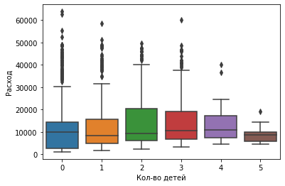

```python
sns.boxplot(data=data, x='children', y='charges').set(ylabel='Расход', xlabel='Кол-во детей')
```

```
[Text(0, 0.5, 'Расход'), Text(0.5, 0, 'Курящий человек')]
```

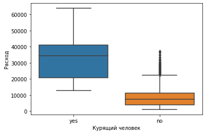

```python
sns.boxplot(data=data, x='smoker', y='charges').set(ylabel='Расход', xlabel='Курящий человек')
```

```
[Text(0, 0.5, 'Расход'), Text(0.5, 0, 'Регион')]
```

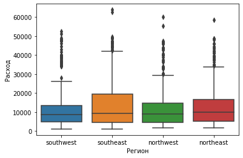

```python
sns.boxplot(data=data, x='region', y='charges').set(ylabel='Расход', xlabel='Регион')
```

```
[Text(0, 0.5, 'Расход'), Text(0.5, 0, 'пол')]
```

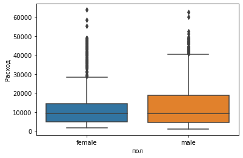

```python
sns.boxplot(data=data, x='sex', y='charges').set(ylabel='Расход', xlabel='пол')
```

#### По построенным boxplot'ам можно сделать выводы: 1) При 2,3,4 детях расходы так или иначе больше, чем при 0,1,5 2) Расход сильно зависит от того, курит человек, или нет. 3) Расход от региона, практически, не зависим. 4) Расход от пола, практчески, независим. Средний доход по полу одинаковый. 5) Так же можно заметить большое количество выбросов.

## 4. Построение модели предсказания и оценка модели.

#### Предсказание модели я умею строить только по 2 признакам(x,y). Но, по предварительному анализу, можно сделать вывод, оценивать по какому-то особенному признакому расход не будет являться правильным и оптимальным.

```python
data.loc[50:60]
```

|  | age | sex | bmi | children | smoker | region | charges |
| --- | --- | --- | --- | --- | --- | --- | --- |
| 50 | 18 | female | 35.6 | 0 | no | northeast | 2,211.1 |
| 51 | 21 | female | 33.6 | 2 | no | northwest | 3,579.8 |
| 52 | 48 | male | 28.0 | 1 | yes | southwest | 23,568.3 |
| 53 | 36 | male | 34.4 | 0 | yes | southeast | 37,742.6 |
| 54 | 40 | female | 28.7 | 3 | no | northwest | 8,059.7 |
| 55 | 58 | male | 37.0 | 2 | yes | northwest | 47,496.5 |
| 56 | 58 | female | 31.8 | 2 | no | northeast | 13,607.4 |
| 57 | 18 | male | 31.7 | 2 | yes | southeast | 34,303.2 |
| 58 | 53 | female | 22.9 | 1 | yes | southeast | 23,244.8 |
| 59 | 34 | female | 37.3 | 2 | no | northwest | 5,989.5 |
| 60 | 43 | male | 27.4 | 3 | no | northeast | 8,606.2 |

#### Для признаков, которые имеют погрупповое распределение(Н: человек курит? да\нет), вес можно установить, как средний расход в этом признаке. У нас получится 5 признака с весами. (sex, children, smoker, region, age)

```python
data.groupby('sex')['charges'].mean()
```

```
sex
female   12,569.6
male     13,956.8
Name: charges, dtype: float64
```

```python
#Значит,вес признака 'sex': if == 'male': 13956.8 if == 'female': 12569.6
#Занесе сразу в специальные переменные
w_sex_male = 13956.8
w_sex_female = 12569.6
#Так же сделаем такие вычисления для children,smoker,region
```

```python
#children
data.groupby('children')['charges'].mean()
```

```
children
0   12,366.0
1   12,731.2
2   15,073.6
3   15,355.3
4   13,850.7
5    8,786.0
Name: charges, dtype: float64
```

```python
w_children_0 = 12366
w_children_1 = 12731.2
w_children_2 = 15073.6
w_children_3 = 15355.3
w_children_4 = 13850.7
w_children_5 = 8786
```

```python
#age
data.groupby('age')['charges'].mean()
```

```
age
18    7,086.2
19    9,747.9
20   10,159.7
21    4,730.5
22   10,012.9
23   12,419.8
24   10,648.0
25    9,838.4
26    6,133.8
27   12,184.7
28    9,069.2
29   10,430.2
30   12,719.1
31   10,197.0
```

[output cut: 34 more lines]

```python
#smoker
data.groupby('smoker')['charges'].mean()
```

```
smoker
no     8,434.3
yes   32,050.2
Name: charges, dtype: float64
```

```python
w_smoker_yes = 32050.2
w_smoker_no = 8434.3
```

```python
#region
data.groupby('region')['charges'].mean()
```

```
region
northeast   13,406.4
northwest   12,417.6
southeast   14,735.4
southwest   12,346.9
Name: charges, dtype: float64
```

```python
w_region_northeast = 13406.4
w_region_northwest = 12417.6
w_region_southeast = 14735.4
w_region_southwest = 12346.9
```

#### Попробуем создать модель, которая будет расчитывать предполагаемый расход.

```python
#Функция, которая будет считать предполагаемый расход
#По каждому параметру добавляется средняя оценка этого параметра, которую мы высчитали ранее.
#Предполагаемый расход будет равен: (сумма цоенок параметров)/количество_параметров

def make_alleged_charges(i):

        alleged_charges = 0
        data_new = data.loc[i]
        one = data_new['age']
        data1 = data[data['age'] == one]
        charges_one = data1.mean()
        one = charges_one['charges']

        w_age = one
        if (data_new['sex'] == 'male'):
            w_sex = w_sex_male
        else:
            w_sex = w_sex_female
        if (data_new['children'] == 0):
            w_children = w_children_0
        elif(data_new['children'] == 1):
                w_children = w_children_1
        elif(data_new['children'] == 2):
                w_children = w_children_2
        elif(data_new['children'] == 3):
                w_children = w_children_3
        elif(data_new['children'] == 4):
                w_children = w_children_4
        elif(data_new['children'] == 5):
                w_children = w_children_5
        if (data_new['smoker']== 'yes'):
            w_smoker = w_smoker_yes
        else:
            w_smoker = w_smoker_no
        if (data_new['region']=='northeast'):
            w_region = w_region_northeast
        elif (data_new['region']=='northwest'):
                w_region = w_region_northwest
        elif (data_new['region']=='southeast'):
                w_region = w_region_southeast
        elif (data_new['region']=='southwest'):
                w_region = w_region_southwest

        alleged_charges = (w_age+w_sex+w_children+w_region+w_smoker)/5
        return alleged_charges

#Создаздим новый список, который будет влючать в себя значения alleged_charges. И добавим его в новый столбец в БД
new_list = []
for i in range(0,1338,1):
    number = make_alleged_charges(i)
    new_list.append(number)


data['alleged_charges'] = new_list

data.loc[500:520]
```

|  | age | sex | bmi | children | smoker | region | charges | alleged_charges |
| --- | --- | --- | --- | --- | --- | --- | --- | --- |
| 500 | 29 | male | 34.4 | 0 | yes | southwest | 36,197.7 | 16,230.0 |
| 501 | 43 | male | 26.0 | 0 | no | northeast | 6,837.4 | 13,486.2 |
| 502 | 51 | male | 23.2 | 1 | yes | southeast | 22,218.1 | 17,831.2 |
| 503 | 19 | male | 30.2 | 0 | yes | southeast | 32,548.3 | 16,571.3 |
| 504 | 38 | female | 28.9 | 1 | no | southeast | 5,974.4 | 11,314.6 |
| 505 | 37 | male | 30.9 | 3 | no | northwest | 6,796.9 | 13,636.8 |
| 506 | 22 | male | 31.4 | 1 | no | northwest | 2,643.3 | 11,510.6 |
| 507 | 21 | male | 23.8 | 2 | no | northwest | 3,077.1 | 10,922.6 |
| 508 | 24 | female | 25.3 | 0 | no | northeast | 3,044.2 | 11,484.9 |
| 509 | 57 | female | 28.7 | 0 | no | southwest | 11,455.3 | 12,432.8 |
| 510 | 56 | male | 32.1 | 1 | no | northeast | 11,763.0 | 12,710.8 |
| 511 | 27 | male | 33.7 | 0 | no | southeast | 2,498.4 | 12,335.4 |
| 512 | 51 | male | 22.4 | 0 | no | northeast | 9,361.3 | 12,769.2 |
| 513 | 19 | male | 30.4 | 0 | no | southwest | 1,256.3 | 11,370.4 |
| 514 | 39 | male | 28.3 | 1 | yes | southwest | 21,082.2 | 16,572.7 |
| 515 | 58 | male | 35.7 | 0 | no | southwest | 11,362.8 | 12,196.6 |
| 516 | 20 | male | 35.3 | 1 | no | southeast | 27,724.3 | 12,003.5 |
| 517 | 45 | male | 30.5 | 2 | no | northwest | 8,413.5 | 12,942.5 |
| 518 | 35 | female | 31.0 | 1 | no | southwest | 5,240.8 | 11,477.8 |
| 519 | 31 | male | 30.9 | 0 | no | northeast | 3,857.8 | 11,672.1 |
| 520 | 50 | female | 27.4 | 0 | no | northeast | 25,656.6 | 12,487.9 |

#### Как можно заметить, предполагаемый расход подобен настоящему только в диапазон средних значений. Сложные алгоритмы построения модели предполагаемых расходов мне еще неизвестна. Рассмотрим соотношение расходов и предполагаемых расходов на графике на графике.

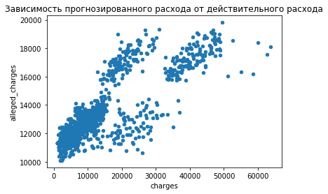

```python
data.plot.scatter(x='charges', y='alleged_charges', title='Зависимость прогнозированного расхода от действительного расхода')
```

#### Как можно заметить, линейной зависимости тут явно нет. Модель была бы идеально,если бы все точки выстраивались на пересечение перпендекуляров из двух точек с одинаковым значением.

## 5. Минимизация квадратичной ошибки.

#### В простейшей постановке задача прогноза значения вещественного признака по прочим признакам решается минимизацией квадратичной функции ошибки. Напишем функцию, которая по двум параметрам w0 и w1 вычисляет квадратичную ошибку приближения зависимости alleged_charges y от charges x прямой линией y=w0+w1∗x.

```python
def get_y(w0, w1, x):
    return w0 + w1*x

def get_error(w0, w1):
    return sum(map(lambda x, y: (y - get_y(w0, w1, x)) ** 2, data.charges, data.alleged_charges))
```

#### Итак, мы решаем задачу: как через облако точек, соответсвующих наблюдениям в нашем наборе данных, в пространстве признаков "charges" и "alleged_charges" провести прямую линию так, чтобы минимизировать функционал. Для начала давайте отобразим хоть какие-то прямые и убедимся, что они плохо передают зависимость alleged_charges от charges. Проведите на последнем графике две прямые, соответствующие значениям параметров ( w0,w1)=(50,0.4) и ( w0,w1)=(9000,0.2).

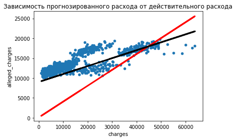

```python
data.plot.scatter(x='charges', y='alleged_charges', title='Зависимость прогнозированного расхода от действительного расхода')

plt.plot(data.charges, get_y(50, 0.4, data.charges), color='red', linewidth=3)

plt.plot(data.charges, get_y(9000, 0.2, data.charges), color='black', linewidth=3)
```

#### Можно заметить, что чёрная линия лежит визуально близко к возможному верному пронозируемому расходу. Нужно минимализировать квадратичную функцию ошибки. С помощью метода оптимизации найдем "оптимальный" наклон прямой, приближающей зависимость прогнозированного расхода от действительного расхода, при фиксированном коэффициенте w0=9000 .

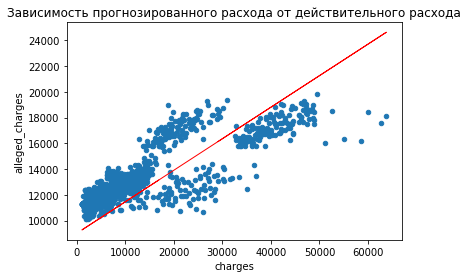

```python
from scipy import optimize
w0 = 9000
w1_opt = optimize.minimize_scalar(lambda x: get_error(w0, x), bounds = [-5, 5]).x

data.plot.scatter(x='charges', y='alleged_charges', title='Зависимость прогнозированного расхода от действительного расхода')

plt.plot(data.charges, get_y(w0, w1_opt, data.charges), color='red', linewidth=1)
```

#### Конечно эта модель не ялвяется оптимальной,т.к. одно значение фиксированное. С помощью метода minimize из scipy.optimize найдем минимум функции, для значений параметра w0 в диапазоне [7000,14000] и w1 - в диапазоне [0, 1000]. Начальная точка – ( w0 , w1 ) = (10000, 0). Используйте метод оптимизации L-BFGS-B (аргумент method метода minimize). Проведем на графике 1 прямую, соответствующую найденным оптимальным значениям параметров w0 и w1 .

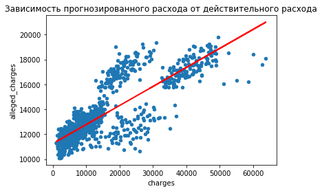

```python
w0_opt, w1_opt = optimize.minimize(lambda w: get_error(w[0], w[1]), (10000, 0), bounds = ((7000, 14000), (0, 1000)), method='L-BFGS-B').x

data.plot.scatter(x='charges', y='alleged_charges', title='Зависимость прогнозированного расхода от действительного расхода')

plt.plot(data.charges, get_y(w0_opt, w1_opt, data.charges), color='red', linewidth=2)
```

#### Данная прямая показывает наилучшее предсказание модели.

### Вся работа была выполнена мной. Использовал свои знания, информацию из курсов (указанных в summary) и документацию pyhton3 (https://docs.python.org/3/). Описывал каждый шаг для более понятного и детального восприятия моей работы. Благодарен за предоставленную возможность, очень интересное исследование.